# 5400 Case Study

Brenna Dunston

2024-10-19

# Case Study-Determining Reliability and Validity of Linear Position Transducers

A important factor of sport performance is power movements like jumping. Having tools to efficiently measures jump performance in athletes is crucial for athlete monitoring. Jump performance in athletes can be measured with the gold standard of force plates, but force plates are not always practical. Linear position transducers are a portable and more practical tool for assessing jump performance. The aim of this statistical analysis was to assess the reliability and validity of the lpt.

Due to the complete data from this study not being publicly available, the data will be simulated.

## Methodological Approach

This study was conducted to investigate concurrent validity. 38 participants completed a counter movement jump on a force plate while simultaneously using a lpt. Validity was assessed via a 95% limits of agreements test (LoA), a paired t-tests (p < .05), and Cohen’s d. A Bland-Altman plot was used to display the LoA. To interpret the Bland-Altman plot, readers should be looking for the following things…

- Where is the mean difference line is in relation to zero? This will provide insight into bias.
- How many points lie outside the limit of agreements lines? Too many points outside the line indicates poor agreement between the two tests.
- What is the distribution of the points on the plot? The points should be scattered evenly across the plot to indicate agreement across a the range of values.
- How large is the range between the 95% limits? A larger range would indicate that there is more variability between testing methods.

Reader’s should then use the paired t-test results to confirm what was observed in the Bland-Altman plot. Look for these numbers in the paired t-test results…

- Mean difference (this will confirm the mean difference from the plot)
- Range of the confidence intervals (how confident are we of the bias?)
- p-value (how extreme are our results? Can we reject the null hypo?)

To see the effect size of any bias found, readers should interpret Cohen’s d using these guidelines…

- 0.0-0.2 is small/negligible
- 0.2-0.5 is small
- 0.5-0.8 is medium
- 0.8 and above is large

In terms of reliability, this study was conducted to investigate test retest reliability. 38 participants conducted the same test (lpt) on two different days. Note the days were close enough together that this could not be considered stability reliability. Relative reliability was assessed using the ICC. Absolute reliability was assessed by calculating the standard error of measurement (SEM). Readers should use the following guides to interpret the calculated ICC…

- 0.5 or below is poor
- 0.5-0.75 is moderate
- 0.75-0.80 is good
- 0.90 and above is excellent

Readers should be looking for an SEM closer to zero, as this would indicate less measurement error and higher reliability. In addition to calculating the SEM, it has also been calculated in terms of percentage of the mean. A lower percentage would indicate less measurement relative to the mean.

While not a direct measure of reliability, the coefficient of variation (CoV) has also been included to assess relative variability of the data. A lower CoV % would indicate higher reliability because it indicates better consistency.

## Descriptive Statistics

```r
set.seed(5400)
participant_v <- c(1:38)
force_plate <- rnorm(38, mean = 20.7, sd = 2.75) #simulate data for the force plate
lpt <- rnorm(38, mean = 27.7, sd = 2.75) #simulate data for the lpt
validity_data <- tibble(participant_v, force_plate, lpt)
validity_data <- validity_data |>
  group_by(participant_v) |>
  mutate(difference = lpt - force_plate,
         mean_value = mean(force_plate:lpt)
         )
set.seed(5400)
day_1 <- rnorm(38, mean = 34.4, sd = 3.8) #simulate data for test using mean & sd for trial 1
day_2 <- (day_1 * 0.99) + runif(38, min = -2.6, max = 2.6) #simulate data for the re-test by using the mean and sd for trial 2
reliability_data <- tibble(day_1, day_2) |>
  mutate(participant_r = as.factor(c(1:38)),
         difference = day_2 - day_1) |>
  select(participant_r, day_1, day_2, difference)
icc_reliability <- reliability_data |>
  select(day_1, day_2)
```

Reliability (Test-Retest) Data Table

```r
test_retest_data <- tibble(day_1, day_2) |>
  mutate(participant_r = as.factor(c(1:38))) |>
  select(participant_r, day_1, day_2)
print(test_retest_data)
```

```
## # A tibble: 38 × 3
##    participant_r day_1 day_2
##    <fct>         <dbl> <dbl>
##  1 1              41.4  38.5
##  2 2              39.4  40.5
##  3 3              38.3  35.8
##  4 4              31.8  32.7
##  5 5              40.4  41.5
##  6 6              34.9  32.1
##  7 7              34.1  36.2
##  8 8              32.8  33.7
##  9 9              31.4  29.8
## 10 10             44.6  42.6
## # ℹ 28 more rows
```

Summary Statistics of Reliability

```r
r_summ <- tibble(day_1, day_2) |>
  summary()
r_summ
```

```
##      day_1           day_2
##  Min.   :28.68   Min.   :27.91
##  1st Qu.:32.85   1st Qu.:32.28
##  Median :35.54   Median :34.33
##  Mean   :35.53   Mean   :34.84
##  3rd Qu.:38.12   3rd Qu.:37.87
##  Max.   :44.61   Max.   :42.77
```

```r
sd_1 <- sd(day_1)
sd_2 <- sd(day_2)
cat(paste("The standard deviation of trial one is:", sd_1, 'and the standard deviation of trial two is', sd_2))
```

```
## The standard deviation of trial one is: 3.79386171277445 and the standard deviation of trial two is 3.87033055045858
```

```r
var_1 <- var(day_1)
var_2 <- var(day_2)
cat(paste("The variance of trial one is:", var_1, 'and the variance of trial two is', var_2))
```

```
## The variance of trial one is: 14.3933866956559 and the variance of trial two is 14.979458569813
```

Concurrent Validity Data Table

```r
concurrent_validity_data <- tibble(force_plate, lpt) |>
  mutate(participant_v = as.factor(c(1:38))) |>
  select(participant_v, force_plate, lpt)
concurrent_validity_data
```

```
## # A tibble: 38 × 3
##    participant_v force_plate   lpt
##    <fct>               <dbl> <dbl>
##  1 1                    25.8  22.6
##  2 2                    24.3  24.3
##  3 3                    23.5  30.0
##  4 4                    18.8  33.0
##  5 5                    25.0  25.8
##  6 6                    21.0  26.0
##  7 7                    20.5  24.9
##  8 8                    19.5  30.2
##  9 9                    18.5  26.5
## 10 10                   28.1  22.9
## # ℹ 28 more rows
```

Summary Statistics of Validity

```r
v_summ <- tibble(force_plate, lpt) |>
  summary()
v_summ
```

```
##   force_plate         lpt
##  Min.   :16.56   Min.   :21.05
##  1st Qu.:19.58   1st Qu.:25.50
##  Median :21.53   Median :27.74
##  Mean   :21.52   Mean   :27.51
##  3rd Qu.:23.39   3rd Qu.:29.99
##  Max.   :28.09   Max.   :33.43
```

```r
sd_fp <- sd(force_plate)
sd_lpt <- sd(lpt)
cat(paste("The standard deviation of the force plate trial is:", sd_fp, 'and the standard deviation of the LPT trial is', sd_lpt))
```

```
## The standard deviation of the force plate trial is: 2.74555781845519 and the standard deviation of the LPT trial is 3.03481743512916
```

```r
var_fp <- var(force_plate)
var_lpt <- var(lpt)
cat(paste("The variance of the force plate trial one is:", var_fp, 'and the variance of the lpt trial is', var_lpt))
```

```
## The variance of the force plate trial one is: 7.53808773448043 and the variance of the lpt trial is 9.21011686456394
```

## Validity Results

```r
set.seed(5400)
participant_v <- c(1:38)
force_plate <- rnorm(38, mean = 20.7, sd = 2.75) #simulate data for the force plate
lpt <- rnorm(38, mean = 27.7, sd = 2.75) #simulate data for the lpt
validity_data <- tibble(participant_v, force_plate, lpt)
validity_data <- validity_data |>
  group_by(participant_v) |>
  mutate(difference = lpt - force_plate,
         mean_value = mean(force_plate:lpt)
         )
validity_data
```

```
## # A tibble: 38 × 5
## # Groups:   participant_v [38]
##    participant_v force_plate   lpt difference mean_value
##            <int>       <dbl> <dbl>      <dbl>      <dbl>
##  1             1        25.8  22.6   -3.16          24.3
##  2             2        24.3  24.3   -0.00584       24.3
##  3             3        23.5  30.0    6.51          26.5
##  4             4        18.8  33.0   14.2           25.8
##  5             5        25.0  25.8    0.814         25.0
##  6             6        21.0  26.0    4.96          23.0
##  7             7        20.5  24.9    4.40          22.5
##  8             8        19.5  30.2   10.7           24.5
##  9             9        18.5  26.5    8.02          22.5
## 10            10        28.1  22.9   -5.21          25.6
## # ℹ 28 more rows
```

```r
mean_difference <- mean(validity_data$difference)
cat(paste('The mean difference is', round(mean_difference, 2)))
```

```
## The mean difference is 5.99
```

### Bland-Altman Plot

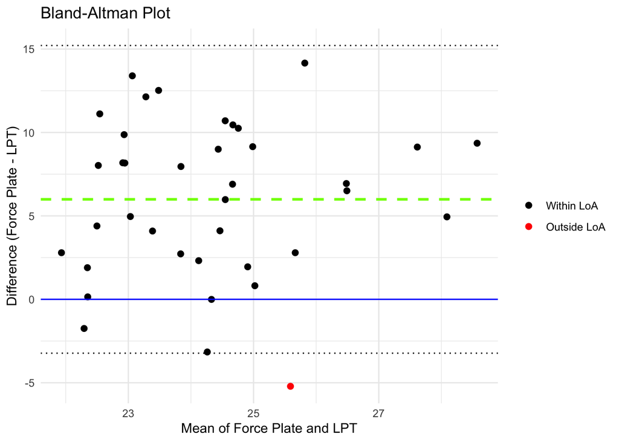

```r
sd_difference <- sd(validity_data$difference)
loa_upper <- mean_difference + 1.96 * sd_difference
loa_lower <- mean_difference - 1.96 * sd_difference
validity_data$outside_loa <- (validity_data$difference < loa_lower) | (validity_data$difference > loa_upper)
validity_data |>
  ggplot(aes(x = mean_value, y = difference)) +
  geom_point(aes(color = outside_loa), size = 2) +
  geom_hline(yintercept = mean_difference, color = "chartreuse", linetype = "dashed", linewidth=1) +
  geom_hline(yintercept = loa_upper, color = "black", linetype = "dotted") +   # Upper limit
  geom_hline(yintercept = loa_lower, color = "black", linetype = "dotted") +   # Lower limit
  geom_hline(yintercept = 0, color = "blue", linetype = "solid") +
  labs(title = "Bland-Altman Plot",
       x = "Mean of Force Plate and LPT",
       y = "Difference (Force Plate - LPT)") +
  scale_color_manual(values = c("black", "red"),
                     labels = c("Within LoA", "Outside LoA")) +  # Custom colors
  theme_minimal() +
  theme(legend.title = element_blank())
```

```r
t.test(lpt, force_plate, paired=T)
```

```
##
##  Paired t-test
##
## data:  lpt and force_plate
## t = 7.8515, df = 37, p-value = 2.147e-09
## alternative hypothesis: true mean difference is not equal to 0
## 95 percent confidence interval:
##  4.445581 7.538156
## sample estimates:
## mean difference
##        5.991869
```

The results of the paired t-test above confirm that the mean difference is 5.99 with confidence levels of 4.45-7.54. This is signficantly different from zero and indicates that one test overestimates the other. The p-value of 2.147e-09 indicates that our result is quite extreme and we can reject the hypothesis that the mean is equal to zero. Let’s calculate the effect size of the bias now.

### Cohen’s d

```r
effect_size <- mean(validity_data$difference) / sd(validity_data$difference)
cat(paste('The calculated cohens d is', round(effect_size, 2), 'which indicates that the effect size is large.'))
```

```
## The calculated cohens d is 1.27 which indicates that the effect size is large.
```

Because the cohen’s d is quite large, it suggests that the two tests do not align well and they may not be measuring the construct of jump height similarly.

## Reliability Results

```r
set.seed(5400)
day_1 <- rnorm(38, mean = 34.4, sd = 3.8) #simulate data for test using mean & sd for trial 1
day_2 <- (day_1 * 0.99) + runif(38, min = -2.6, max = 2.6) #simulate data for the re-test by using the mean and sd for trial 2
reliability_data <- tibble(day_1, day_2) |>
  mutate(participant_r = as.factor(c(1:38)),
         difference = day_2 - day_1) |>
  select(participant_r, day_1, day_2, difference) #change this to order
reliability_data
```

```
## # A tibble: 38 × 4
##    participant_r day_1 day_2 difference
##    <fct>         <dbl> <dbl>      <dbl>
##  1 1              41.4  38.5     -2.85
##  2 2              39.4  40.5      1.05
##  3 3              38.3  35.8     -2.41
##  4 4              31.8  32.7      0.852
##  5 5              40.4  41.5      1.15
##  6 6              34.9  32.1     -2.76
##  7 7              34.1  36.2      2.12
##  8 8              32.8  33.7      0.883
##  9 9              31.4  29.8     -1.62
## 10 10             44.6  42.6     -2.04
## # ℹ 28 more rows
```

### Visualization of Test Retest Reliability

A quick analysis of the reliability shows a pearson coefficient of 0.92 (upper right) and rough visualizations of the two trials of lpt.

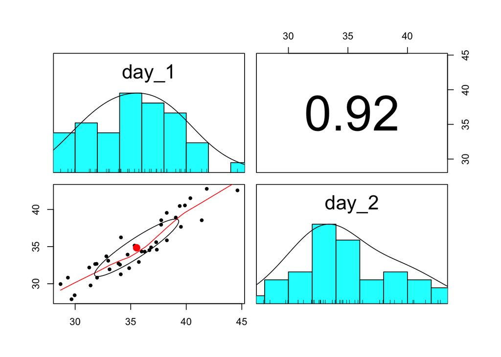

```r
pairs.panels(icc_reliability) #use the df made for the ICC code found below
```

Let’s take a closer look at that scatter plot of the the two trials…

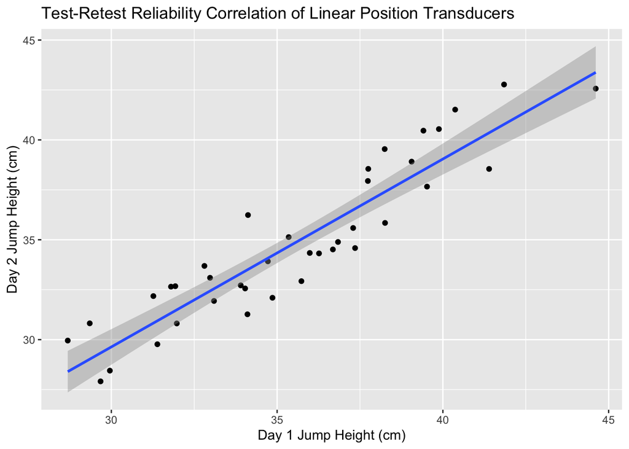

```r
reliability_data |>
  ggplot(aes(x = day_1, y = day_2)) +
  geom_point() +
  geom_smooth(method = 'lm') +
  labs(title = 'Test-Retest Reliability Correlation of Linear Position Transducers', x = 'Day 1 Jump Height (cm)', y = 'Day 2 Jump Height (cm)')
```

### ICC of Reliability

```r
icc_reliability <- reliability_data |>
  select(day_1, day_2)
icc_result <- ICC(icc_reliability)
icc_value <- icc_result$results$ICC[2]
cat(paste('The ICC between trial one and trial two was found to be', round(icc_value, 2),', which is considered to be excellent reliability'))
```

```
## The ICC between trial one and trial two was found to be 0.91 , which is considered to be excellent reliability
```

The ICC calculated above falls into the excellent reliability range according to the criterion presented in the methodology. Now let’s take a look at the SEM…

Standard Error of Measurement

```r
SEM_1 <- sd(reliability_data$difference)/sqrt(2)
SEM_2 <- (sd(c(reliability_data$day_1, reliability_data$day_2))) * sqrt(1 - icc_value)
cat(paste('The SEM is', round(SEM_1, 2), 'when calculated from the difference scores and', round(SEM_2, 2), "when calculated from the ICC result."))
```

```
## The SEM is 1.07 when calculated from the difference scores and 1.15 when calculated from the ICC result.
```

This SEM indicates that the observed score may vary 1.15 cm from the participants true score due to measurement error. If we consider this in relation to the mean…

```r
mean_1 <- 35.5322263
mean_2 <- 35.8394289
sem_percent <- ((1.15 / ((mean_1 + mean_2) / 2)) * 100)
cat(paste('The SEM is', round(sem_percent, 2), '% of the mean score.'))
```

```
## The SEM is 3.22 % of the mean score.
```

This would indicate that the SEM is relatively low in proportion to the mean score.

### Coefficient of Variation

```r
sd_combined <- sqrt(((38 - 1) * sd_1^2 + (38 - 1) * sd_2^2) / (38 + 38 - 2))
CoV <- (sd_combined / ((mean_1 + mean_2) / 2)) * 100
cat(paste('The coefficient of variation is', round(CoV, 2), '%.'))
```

```
## The coefficient of variation is 10.74 %.
```

The CoV is not a direct measure of reliability, but the lower value obtained above indicates low to moderate variability, which is good in terms of reliability. Note CoV does not account for random error from true variability.

### Minimal Detectable Change

```r
md <- SEM_2 * sqrt(2) * 1.96
cat(paste("Based on the 95% Confidence Interval, a participant's score would need to change by a minimum of", round(md, 2), "cm between trials to be considered significant or meaningful."))
```

```
## Based on the 95% Confidence Interval, a participant's score would need to change by a minimum of 3.19 cm between trials to be considered significant or meaningful.
```

## Evaluation and Concluding Remarks

Due to the mean difference of 5.99 found using a Bland-Altman plot and confirmed with a paired t-test, the lpt seems to overestimate jump height by a factor of 5.99 cm. The effect size of 1.27 indicates that the differences between the two methods were pronounced and do not align well. Because of these differences, the lpt was determined to have low concurrent validity in assessing jump height within the participant group assessed.

Overall, after statistical analysis of the study results, the Linear Position Transducer (lpt) can be considered a jump height test with high test-retest reliability but low concurrent validity.